# TBCR analysis

Downstream analysis on TRUST output files

Tian Xu (xu_tian@stu.pku.edu.cn), Zexian Zeng(zexianzeng@pku.edu.cn)

Center for Life Sciences & Center for Quantitative Biology

Academy for Advanced Interdisciplinary Studies, Peking University

Lab website: http://cqb.pku.edu.cn/zenglab/

## Part 0. Preparations of coding

1. log in your account on the server by

   `ssh -i {Path_to_your_private_key_file} -p 16122 {Your_username}@162.105.160.16`
   - If the system of your laptop is windows, you should download and install [MobaXterm](https://mobaxterm.mobatek.net)
   - If you are using MacOS, you can directly use your terminal.
2. Set up your environment variables
   - Make sure you are at your root directory after logging in via `pwd`
   - Make a new file namely ".bashrc" via `touch .bashrc`
   - Writing the path of conda into your environment variable file by `vim .bashrc` and copy the following contents into it:

   ```bash
   # .bashrc

   # Source global definitions
   if [ -f /etc/bashrc ]; then
       . /etc/bashrc
   fi

   # User specific environment
   if ! [[ "$PATH" =~ "$HOME/.local/bin:$HOME/bin:" ]]
   then
   	PATH="$HOME/.local/bin:$HOME/bin:$PATH"
   fi
   export PATH

   # Uncomment the following line if you don't like systemctl's auto-paging feature:
   # export SYSTEMD_PAGER=

   # User specific aliases and functions

   # >>> conda initialize >>>
   # !! Contents within this block are managed by 'conda init' !!
   __conda_setup="$('/lustre1/share/miniconda3/bin/conda' 'shell.bash' 'hook' 2> /dev/null)"
   if [ $? -eq 0 ]; then
   	eval "$__conda_setup"
   else
   	if [ -f "/lustre1/share/miniconda3/etc/profile.d/conda.sh" ]; then
   		. "/lustre1/share/miniconda3/etc/profile.d/conda.sh"
   	else
   		export PATH="/lustre1/share/miniconda3/bin:$PATH"
   	fi
   fi
   unset __conda_setup
   ```

   - Type `:` and then `wq!`. This will save the changes of .bashrc file.
   - Finally, use `source .bashrc` to activate your environment variables.
   - Simply type `conda` and you'll see the usage of conda. It works!!!

   ```
   conda env list
   ```

3. Enter the virtual environment by typing `conda activate airr`  
   All the packages used in this class have been installed as follows.  
   *Note: You **don't need to** run the codes in this section, unless you want to build your own environment.*

```
conda install -c bioconda -c conda-forge r-ggplot2 r-dplyr r-ggpubr
```

### Data

All the TRUST output data that we will use in this class can be found at `/lustre1/share/airr/data`

In this folder, there are two subfolders, `TRUST_output` and `OV_results`. `TRUST_output` folder storages output files of one sample from TCGA RNA-seq data processed by TRUST3 tool. `OV_results` folder storages *_report.tsv* files extracted by TRUST3 in TCGA-OV cohort (375 samples).

```
cd /lustre1/share/airr/data/TRUST_output
ls

TRUST_output
    ├── *_anno.fa  ## fasta format for the annotation of the consensus assembly
    ├── *_assembled_reads.fa  ## complete read sequence of the assemblies
    ├── *_cdr3.out  ## the CDR1,2,3 and gene information for each consensus assemblies
    ├── *_cluster.out  ## cluster information of consensus assemblies
    ├── *_evo.out  ## evolution information of final TCR/BCR sequences
    ├── *_final.out  ## final contigs and corresponding nucleotide weight
    ├── *_full.fa  ## complete TCR/BCR sequences file
    ├── *_raw.out   ## raw contigs and corresponding nucleotide weight
    ├── *_report.tsv  ## report file focusing on CDR3 and is compatible with other repertoire analysis tool such as VDJTools.
    └── *_simplerep.out  ## simplified report file
```

The raw RNA-seq data is from [TCGA public dataset](https://portal.gdc.cancer.gov/).

### Output

Before we start, `cd` into your own home, and create a folder for the outputs of this class.

```
pwd
cd ~
mkdir airr_output
cd airr_output
```

Now, we have prepared everything that will be used in our class.

## Part 1. Obtain clonetype information.

### A. Load consensus assemblies information

Firstly, open **R**.

```
R
```

*Note: The working directory is the folder where you run R. Any relative path is relative to the working directory. You can change it with the function `setwd`*

Load the packages we will use.

```
library(ggplot2)
library(dplyr)
library(ggpubr)
```

Then we load consensus assemblies table into R and take a look.

```
consensus_df <- read.table("/lustre1/share/airr/data/TRUST_output/TCGA-02-0055-01A-01R-1849-01_cdr3.out", sep='\t')
print(head(consensus_df))
```

We can see that there is no column name. So we should add the column names by ourselves.

```
colnames(consensus_df) <- c("consensus_id","index_within_consensus","V_gene","D_gene","J_gene","C_gene","CDR1","CDR2","CDR3","CDR3_score","read_fragment_count","CDR3_germline_similarity")
print(head(consensus_df))
```

*About CDR3_score: For CDR3 score, 0.00 means partial CDR3, score 0.01 means CDR3 with imputed nucleotides and other numbers means the motif signal strength with 1.00 as strongest.*

### B. Extract TCR and BCR information individually

We should notice that TRUST3 algorithm could call TCR and BCR **at the same time**, so we need to separate the information of TCR and BCR sequences from the table.

```
## Extract TCR information
TCR_df <- consensus_df %>%
  filter(grepl("^TR", V_gene) |
         grepl("^TR", D_gene) |
         grepl("^TR", J_gene) |
         grepl("^TR", C_gene))

# Extract BCR information
BCR_df <- consensus_df %>%
  filter(grepl("^IG", V_gene) |
         grepl("^IG", D_gene) |
         grepl("^IG", J_gene) |
         grepl("^IG", C_gene))

print(head(TCR_df))
```

### C. Show the consensus assemblies information of the sample

Then we can count the the number of different assemblies and their frequency in this sample.

```
BCR_consensus_count <- table(factor(BCR_df$consensus_id, levels = unique(BCR_df$consensus_id)))
BCR_consensus_df <- as.data.frame(BCR_consensus_count)
print(head(BCR_consensus_df))
```

```
## count the number of different assemblies in the sample
print(nrow(BCR_consensus_df))
```

```
## count the number of different assemblies in the sample
png('BCR_consensus_frequency_distribution.png')
p <- ggplot(BCR_consensus_df, aes(x = Freq)) +
  geom_histogram(binwidth = 1, fill = "skyblue", color = "black", alpha = 0.7) +
  labs(title = "Frequency Distribution of Consensus Assemblies",
       x = "Frequency (Freq)",
       y = "Count") +
  theme_minimal()
print(p)
dev.off()
```

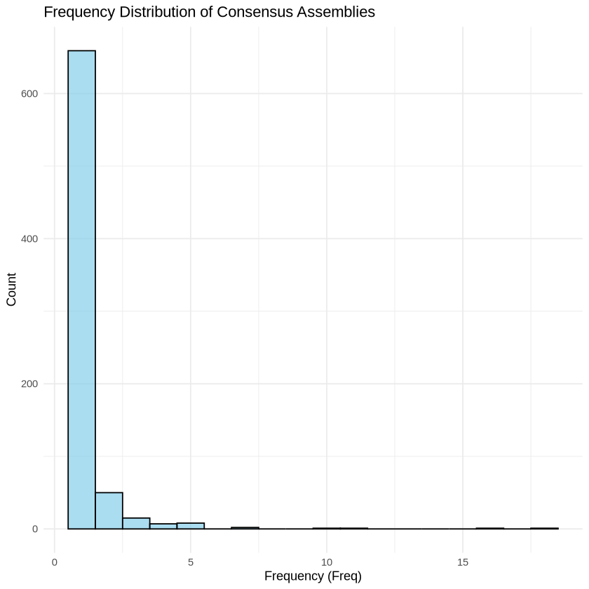

## Part 2. Obtain gene usage information.

### A. Load CDR3 information

Firstly, we load CDR3 table into R and take a look

```
air_df <- read.table("/lustre1/share/airr/data/TRUST_output/TCGA-02-0055-01A-01R-1849-01_report.tsv", sep='\t')
print(head(air_df))
```

Also, we should add column names to the table.

```
colnames(air_df) <- c("count","frequency","CDR3nt","CDR3aa","V","D","J","C")
print(head(air_df))
```

*Note: **frequency** column was calculated by TCR and BCR individually.*

### B. Extract TCR and BCR information individually

So we should deal with the information of TCR and BCR separately. Meanwhile, we want to focus on the usage of certain genes. Thus, it's necessary to extract rows by TCR/BCR chains.

```
## Extract rows of TCR alpha chain
TRA_df <- air_df %>%
  filter(grepl("^TRAV", V) |
         grepl("^TRAJ", J) |
         grepl("^TRAC", C))

print(head(TRA_df))

## Extract rows of BCR heavy chain
IGH_df <- air_df %>%
  filter(grepl("^IGHV", V) |
         grepl("^IGHD", D) |
         grepl("^IGHJ", J) |
         grepl("^IGHC", C))

print(head(IGH_df))
```

*Note: No **D gene** is present on the alpha chain of TCR and the light chain of BCR.*

### C. Calculate gene usage frequency

We can try to calculate the IGHV gene usage frequency first.

```
##  Group by V columns, calculate the sum of the counts for each group, and calculate the usage frequency
usage_IGHV_df <- IGH_df %>%
  group_by(V) %>%
  summarise(total_count = sum(count)) %>%
  mutate(usage_frequency = total_count / sum(total_count))

##  For ease of reading, we sort the usage_frequency column in descending order
usage_IGHV_df <- usage_IGHV_df %>%
  arrange(desc(usage_frequency))

usage_IGHV_df <- as.data.frame(usage_IGHV_df)

print(head(usage_IGHV_df))
```

Then we visualize the result.

```
# select the top 10 genes
top_10_IGHV_usage_df <- usage_IGHV_df[1:10,]

p <- ggplot(top_10_IGHV_usage_df, aes(x = reorder(V, -usage_frequency), y = usage_frequency)) +
  geom_bar(stat = "identity", fill = "skyblue", color = "black", alpha = 0.7) +
  labs(title = "Top 10 IGHV Gene Usage Frequency",
       x = "V Gene",
       y = "Usage Frequency") +
  theme_minimal() +
  theme(axis.text.x = element_text(angle = 45, hjust = 1))

png('top10_IGHV_genes.png')
print(p)
dev.off()
```

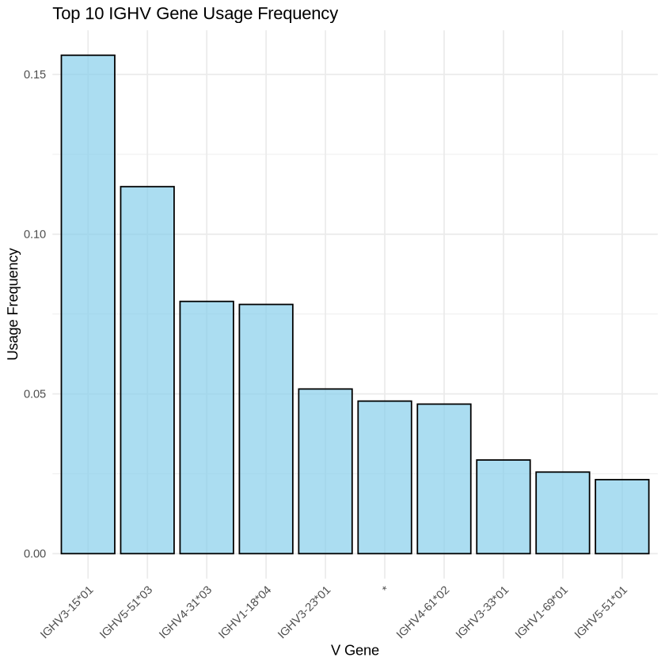

For IGHJ gene usage, it's the same process.

```
##  Group by J columns, calculate the sum of the counts for each group, and calculate the usage frequency
usage_IGHJ_df <- IGH_df %>%
  group_by(J) %>%
  summarise(total_count = sum(count)) %>%
  mutate(usage_frequency = total_count / sum(total_count))

##  For ease of reading, we sort the usage_frequency column in descending order
usage_IGHJ_df <- usage_IGHJ_df %>%
  arrange(desc(usage_frequency))

usage_IGHJ_df <- as.data.frame(usage_IGHJ_df)

print(head(usage_IGHJ_df))
```

```
# select the top 10 genes
top_10_IGHJ_usage_df <- usage_IGHJ_df[1:10,]

p <- ggplot(top_10_IGHJ_usage_df, aes(x = reorder(J, -usage_frequency), y = usage_frequency)) +
  geom_bar(stat = "identity", fill = "skyblue", color = "black", alpha = 0.7) +
  labs(title = "Top 10 IGHJ Gene Usage Frequency",
       x = "J Gene",
       y = "Usage Frequency") +
  theme_minimal() +
  theme(axis.text.x = element_text(angle = 45, hjust = 1))

png('top10_IGHJ_genes.png')
print(p)
dev.off()
```

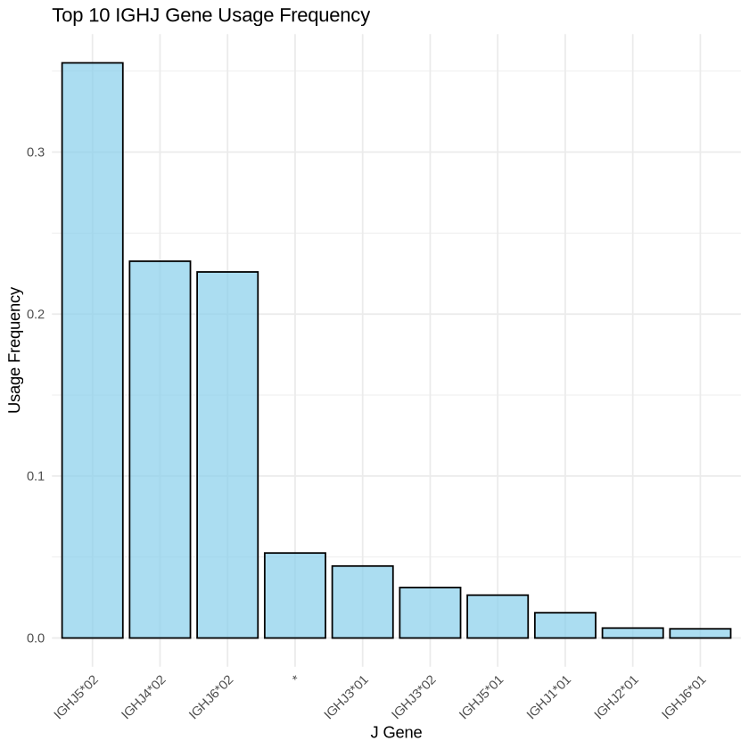

It is also important to calculate the frequency of the joint distribution of the V and J genes.

```
##  Group by V and J columns, calculate the sum of the counts for each group, and calculate the usage frequency
usage_VJ_df <- IGH_df %>%
  group_by(V, J) %>%
  summarise(total_count = sum(count), .groups = 'drop') %>%   ## remove the combined group column
  mutate(usage_frequency = total_count / sum(total_count)) %>%
  arrange(desc(usage_frequency))

usage_VJ_df <- as.data.frame(usage_VJ_df)

print(head(usage_VJ_df))
```

Then we visualize the result with heatmap.

```
p <- ggplot(usage_VJ_df, aes(x = V, y = J, fill = total_count)) +
  geom_tile(color = "white") +
  scale_fill_gradient(low = "white", high = "darkblue") +
  labs(title = "Heatmap of V and J Gene Counts", x = "V Gene", y = "J Gene") +
  theme_minimal() +
  theme(
    axis.text.x = element_text(angle = 45, hjust = 1),
    panel.grid = element_blank(),
    panel.background = element_blank()
  )

png("heatmap_VJ.png", width = 12, height = 6, units = "in", res = 300)
p
dev.off()
```

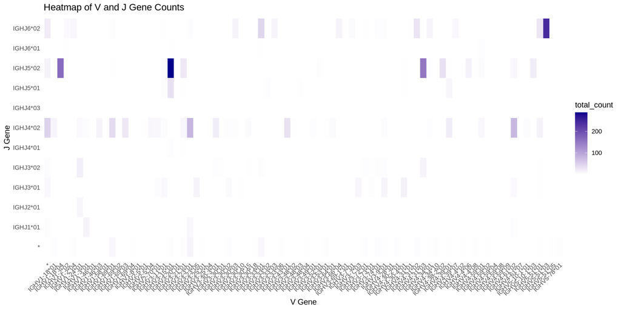

## Part 3. Calculate the distribution of CDR3 length

Firstly, some amino acid sequences of CDR3 is incomplete in `IGH_df` table. So before processing, we should remove those sequences.

```
IGH_filter_df <- IGH_df[IGH_df$CDR3aa != "partial",]
print(head(IGH_filter_df))
```

We can now count the character lengths in `CDR3nt` column and `CDR3aa` column.

```
IGH_filter_df <- IGH_filter_df %>%
  mutate(
    nt_length = nchar(CDR3nt),
    aa_length = nchar(CDR3aa)
  )

print(head(IGH_filter_df))
```

Then, we can calculate the CDR3 sequence length distribution by `nt_length` or `aa_length` column.  
Firstly, we use `nt_length` column.

```
##  Group by nt_length column, calculate the sum of the counts for each group
nt_length_df <- IGH_filter_df %>%
  group_by(nt_length) %>%
  summarise(total_count = sum(count))

nt_length_df <- as.data.frame(nt_length_df)

print(head(nt_length_df, 10))
```

We can visualize the result.

```
p <- ggplot(nt_length_df, aes(x = nt_length, y = total_count)) +
  geom_col(fill = "skyblue", color = "black", alpha = 0.8) +
  labs(title = "Histogram of Nucleotide Length of CDR3 Sequence",
       x = "Nucleotide Length",
       y = "Total Count") +
  theme_minimal()

png("CDR3_nt_length_distribution.png", width = 8, height = 6, units = "in", res = 300)
p
dev.off()
```

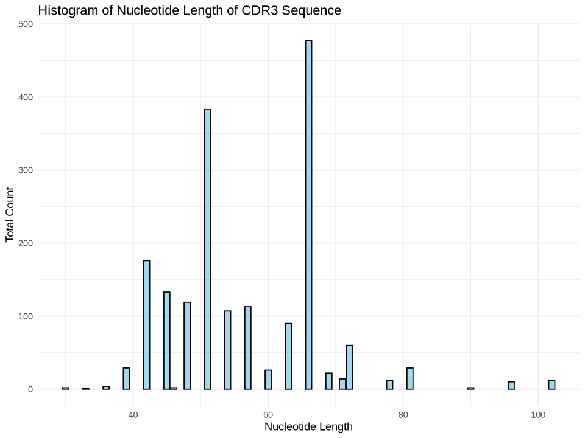

For amino acid sequence, it's the same.

```
##  Group by aa_length column, calculate the sum of the counts for each group
aa_length_df <- IGH_filter_df %>%
  group_by(aa_length) %>%
  summarise(total_count = sum(count))

aa_length_df <- as.data.frame(aa_length_df)

print(head(aa_length_df, 10))
```

We can visualize the result.

```
p <- ggplot(aa_length_df, aes(x = aa_length, y = total_count)) +
  geom_col(fill = "skyblue", color = "black", alpha = 0.8) +
  labs(title = "Histogram of Amino Acid Length of CDR3 Sequence",
       x = "Amino Acid Length",
       y = "Total Count") +
  theme_minimal()

png("CDR3_aa_length_distribution.png", width = 8, height = 6, units = "in", res = 300)
p
dev.off()
```

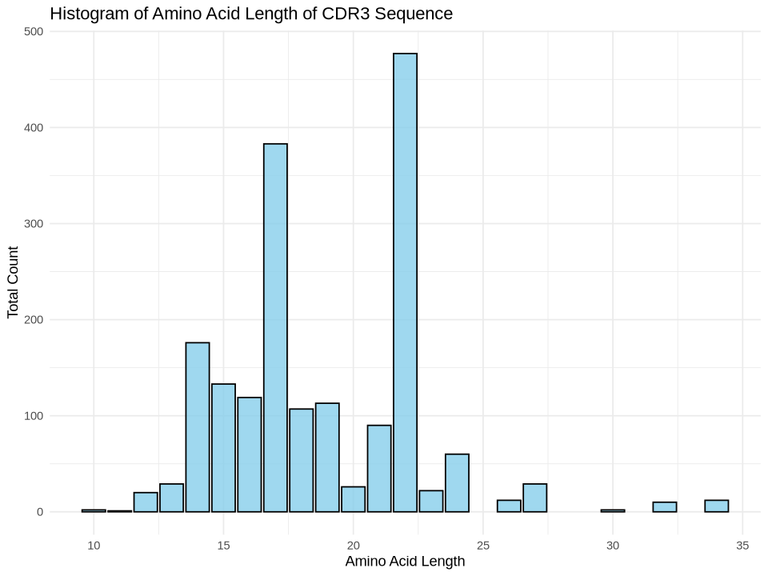

## Part 4. Calculate TCR/BCR diversity index of each sample

Before we discuss TCR/BCR diversity, we should define some indices to quantify the diversity of AIRR.  
It has been introduced these indices to describe one's AIRR diversity (from [Chiffelle et al.](https://www.sciencedirect.com/science/article/pii/S0958166920301051)):

- `raw diversity`: Number of unique CDR3 sequence.
- `clonotypes per thousand kilo reads (CPK)`: (Unique CDR3 count / Total reads) * 1000.
- `entropy`:
  $$H(X) = -\sum_{i=1}^{N} p_i \log p_i$$
  where $p_i$ is the frequency of sequence $i$ in the repertoire and $N$ is the total number of unique sequences.
- `clonality`: measures the dominance of clones in a repertoire.
  $$Clonality = 1-\frac{H(X)}{log N}$$
- `Gini-Simpson index`: the probability of two entities being chosen randomly to not belong to the same species.
  $$Gini-Simpson index = 1-\sum_{i=1}^{N} p_i^2$$

After knowing those indices, we can calculate them of each sample.

**Note: Due to the heavy chain determines the binding capacity of BCR and beta chain for TCR, we only focus the heavy/beta chain diversity in the practice.**

### A. Test on previous sample

First, load the CDR3 sequence information.

```
air_df <- read.table("/lustre1/share/airr/data/TRUST_output/TCGA-02-0055-01A-01R-1849-01_report.tsv", sep='\t')
colnames(air_df) <- c("count","frequency","CDR3nt","CDR3aa","V","D","J","C")
print(head(air_df))
```

Then, extract rows of heavy chain of BCR.

```
IGH_df <- air_df %>%
  filter(grepl("^IGHV", V) |
         grepl("^IGHD", D) |
         grepl("^IGHJ", J) |
         grepl("^IGHC", C))

print(head(IGH_df))
```

Now, we can calculate those indices:

- raw diversity:

```
diversity <- nrow(IGH_df)
print(diversity)
```

- CPK:

```
CPK <- diversity/sum(IGH_df$count) *1000
print(CPK)
```

- entropy:

```
freqs <- IGH_df$count/sum(IGH_df$count)
entropy <- -sum(freqs * log2(freqs))
print(entropy)
```

- clonality:

```
clonality <- 1 - (entropy/log2(diversity))
print(clonality)
```

- gini-simpson index:

```
gini <- 1 - sum(freqs * freqs)
print(gini)
```

### B. Test on cohort samples

There is TCGA-OV cohort data under `OV_results` folder. We can calculate indices for each of the samples.

```
## create a data.frame to storage the indices value of each sample
bcr_metrics_df <- data.frame()

## list the files under OV_results folder
files <- list.files("/lustre1/share/airr/data/OV_results")

## Following the code above, the indices for each sample are
## calculated in a loop and stored in bcr_metrics_df
for (file in files) {
  air_df <- read.table(paste0("/lustre1/share/airr/data/OV_results/",file), sep="\t")
  colnames(air_df) <- c("count","frequency","CDR3nt","CDR3aa","V","D","J","C")
  IGH_df <- air_df %>%
  filter(grepl("^IGHV", V) |
         grepl("^IGHD", D) |
         grepl("^IGHJ", J) |
         grepl("^IGHC", C))

  diversity <- nrow(IGH_df)
  CPK <- diversity/sum(IGH_df$count) *1000

  freqs <- IGH_df$count/sum(IGH_df$count)
  entropy <- -sum(freqs * log2(freqs))

  clonality <- 1 - (entropy/log2(diversity))
  gini <- 1 - sum(freqs * freqs)

  bcr_metrics_row <- data.frame(diversity, CPK, entropy, clonality, gini)
  rownames(bcr_metrics_row) <- tools::file_path_sans_ext(basename(file))  # remove the file suffix

  bcr_metrics_df <- rbind(bcr_metrics_df, bcr_metrics_row)
}

print(head(bcr_metrics_df))
write.csv(bcr_metrics_df, "OV_bcr_diversity.csv")
```

### C. Indices correlation

Draw the correlation between `raw diversity` and `entropy`

```
p <- ggplot(bcr_metrics_df,aes(x = bcr_metrics_df$diversity,
                y = bcr_metrics_df$entropy))+
  geom_point()+
  geom_smooth(method = "lm",
              se = F,
              color = "red")+
  theme_classic()+
  stat_cor(data = bcr_metrics_df,
           method = "spearman")

png('diveristy_cor_entropy.png')
print(p)
dev.off()
```

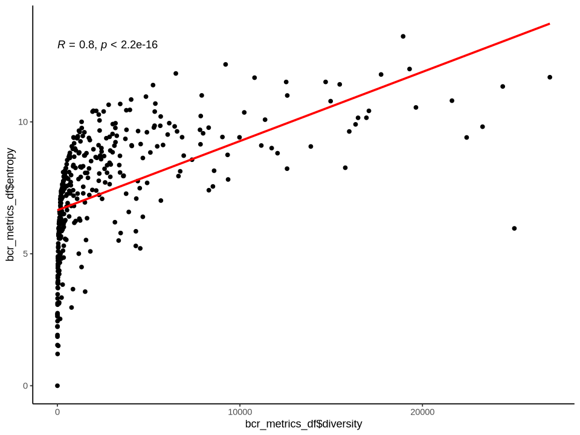

Draw the correlation between `CPK` and `entropy`

```
p <- ggplot(bcr_metrics_df,aes(x = bcr_metrics_df$CPK,
                y = bcr_metrics_df$entropy))+
  geom_point()+
  geom_smooth(method = "lm",
              se = F,
              color = "red")+
  theme_classic()+
  stat_cor(data = bcr_metrics_df,
           method = "spearman")

png('CPK_cor_entropy.png')
print(p)
dev.off()
```

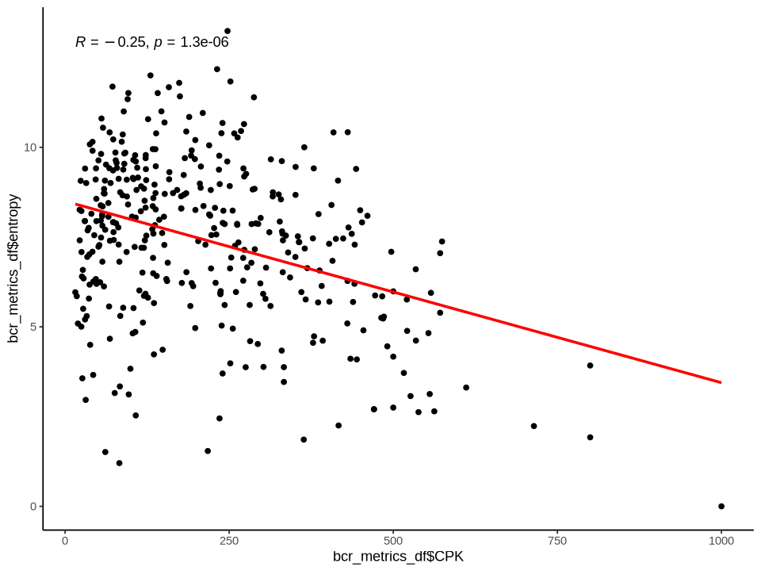

Draw the correlation between `CPK` and `clonality`

```
p <- ggplot(bcr_metrics_df,aes(x = bcr_metrics_df$CPK,
                y = bcr_metrics_df$clonality))+
  geom_point()+
  geom_smooth(method = "lm",
              se = F,
              color = "red")+
  theme_classic()+
  stat_cor(data = bcr_metrics_df,
           method = "spearman")

png('CPK_cor_clonality.png')
print(p)
dev.off()
```

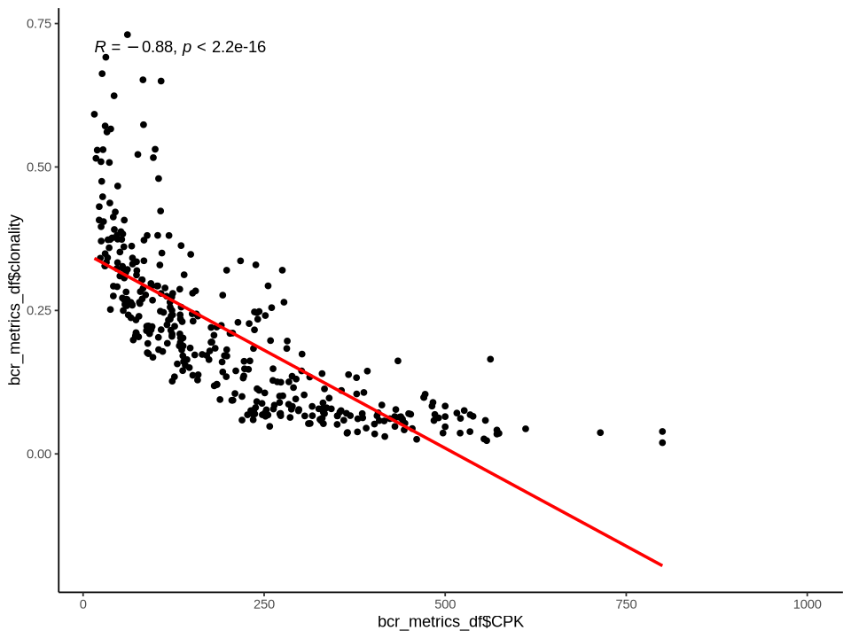

For further analysis, we can integrate clinical information of each sample and compare those indices between different group.